# Analysis of FPAs’ effects on porpoises

Yi Han

2024-07-05

**Email**: yi.han.178@gmail.com  
**Description**: This file conducts following analyses: (1) Mann–Whitney U test evaluates whether porpoise abundance within PAs is significantly higher than that in non-PAs in 2006, using three thresholds (Figure 4a & b). (2) Difference-in-difference analysis evaluates whether porpoise abundance declines in FPAs were less pronounced relative to unprotected areas, using three thresholds (Figure 4c).

## 1. Data preparation

1. Load the file *segment_wise_porpoise_abundance.csv*.

```r
seg_abund_df <- read.csv(file = "../../data/analysis_outputs/animal_distribution/segment_wise_porpoise_abundance.csv")

group_levels <- seg_abund_df$groups[1:150]
seg_abund <- seg_abund_df %>%
      mutate(reserve = as.factor(reserve),
             reserve_without_nj = as.factor(reserve_without_nj),
             f_year = as.factor(f_year),
             abund_ranks = as.factor(abund_ranks),
             groups = factor(groups, levels=group_levels))
head(seg_abund, 5)
```

|  | groups | f_year | year | abund_ranks | segment_mean | reserve | reserve_without_nj |
| --- | --- | --- | --- | --- | --- | --- | --- |
| 1 | [0,10) | 2006 | 2006 | [0,0.05) | 0 | N | N |
| 2 | [10,20) | 2006 | 2006 | [0,0.05) | 0 | N | N |
| 3 | [20,30) | 2006 | 2006 | [0,0.05) | 0 | N | N |
| 4 | [30,40) | 2006 | 2006 | [0,0.05) | 0 | N | N |
| 5 | [40,50) | 2006 | 2006 | [0,0.05) | 0 | N | N |

2. Create a new dataframe with each year as a new column and the corresponding segment-wise abundance as inputs.

```r
seg_abund_wide <- seg_abund %>%
    dplyr::select(groups, f_year, segment_mean, reserve, reserve_without_nj) %>%
    tidyr::pivot_wider(., names_from = f_year, values_from = segment_mean)
head(seg_abund_wide, 5)
```

| groups | reserve | reserve_without_nj | 2006 | 2017 |
| --- | --- | --- | --- | --- |
| [0,10) | N | N | 0 | 0.0950 |
| [10,20) | N | N | 0 | 0.0950 |
| [20,30) | N | N | 0 | 0.0730 |
| [30,40) | N | N | 0 | 0.0165 |
| [40,50) | N | N | 0 | 0.0050 |

```r
str(seg_abund_wide)
```

```
tibble [150 × 5] (S3: tbl_df/tbl/data.frame)
 $ groups            : Factor w/ 150 levels "[0,10)","[10,20)",..: 1 2 3 4 5 6 7 8 9 10 ...
 $ reserve           : Factor w/ 2 levels "N","Y": 1 1 1 1 1 1 1 1 1 1 ...
 $ reserve_without_nj: Factor w/ 2 levels "N","Y": 1 1 1 1 1 1 1 1 1 1 ...
 $ 2006              : num [1:150] 0 0 0 0 0 0 0 0 0 0 ...
 $ 2017              : num [1:150] 0.095 0.095 0.073 0.0165 0.005 0.005 0.005 0.003 0 0 ...
```

3. Create a new column stores the abundance change between 2006 and 2017.

```r
seg_abund_wide <- seg_abund_wide %>%
    rename(abund_06 = "2006",
           abund_17 = "2017") %>%
    mutate(abund_change = abund_17-abund_06)
head(seg_abund_wide, 5)
```

| groups | reserve | reserve_without_nj | abund_06 | abund_17 | abund_change |
| --- | --- | --- | --- | --- | --- |
| [0,10) | N | N | 0 | 0.0950 | 0.0950 |
| [10,20) | N | N | 0 | 0.0950 | 0.0950 |
| [20,30) | N | N | 0 | 0.0730 | 0.0730 |
| [30,40) | N | N | 0 | 0.0165 | 0.0165 |
| [40,50) | N | N | 0 | 0.0050 | 0.0050 |

```r
cat("\n----Propoise abundance summary statistics in 2006 and 2017----\n")
```

```
----Propoise abundance summary statistics in 2006 and 2017----
```

```r
abund_06 <- summary(seg_abund_wide$abund_06)
abund_17 <- summary(seg_abund_wide$abund_17)
cat("Summary statistics in 2006: \n")
```

```
Summary statistics in 2006:
```

```r
print(abund_06)
```

```
   Min. 1st Qu.  Median    Mean 3rd Qu.    Max.
0.00000 0.03875 0.11325 0.15732 0.20775 0.77000
```

```r
cat("\n")
```

```r
cat("Summary statistics in 2017: \n")
```

```
Summary statistics in 2017:
```

```r
print(abund_17)
```

```
   Min. 1st Qu.  Median    Mean 3rd Qu.    Max.
0.00000 0.01775 0.07500 0.10300 0.14250 0.49500
```

## 2. Analyze effects of FPAs on porpoise abundance

We identified segments with consistently low encounter rates, typically near zero or zero, which likely indicate habitats no longer suitable for porpoises due to environmental degradation or unsuitable habitat characteristics. Including these segments with excessive zeros would distort the effects of protection status on porpoise abundance, as small numerical changes in such low-abundance areas carry different ecological meaning compared to those small changes in areas with higher porpoise abundance. Therefore, to focus on ecologically meaningful changes, we excluded segments with porpoise abundance **< 0.1 porpoise km^-1** in both 2006 and 2017, removing 16 FPA segments and 38 non-FPA segments.

We conducted two supplementary analyses to test the robustness of our conclusions against the inclusion or exclusion of river segments with low porpoise populations. The first analysis excluded all river segments with zero porpoise abundance in both years, and the second excluded segments where porpoise abundance was extremely low, **< 0.05 porpoise km^-1** in both years.

Also see “Section 3.2 Effects of FPAs on porpoise abundance and floodplain habitats” in the main text and Appendix S6 & S8 for details.

### 2.1 Mann–Whitney U test

**The Mann–Whitney U test evaluates whether porpoise abundance within PAs is significantly higher than that in non-PAs in 2006, using three thresholds.**

```r
thresholds <- c(0.00001, 0.05, 0.1)

for (threshold in thresholds) {
  cat("\n----------- Results for Exclusion Abundance < ", threshold, " porpoise km-1 -----------\n")

  seg_abund_wide_exl <- seg_abund_wide |>
    filter(!(abund_06 < threshold & abund_17 < threshold))  |>
    droplevels()

  cat("\n----Number of Segments excluded----\n")
  seg_abund_low <- seg_abund_wide %>%
    filter((abund_06 < threshold & abund_17 < threshold))
  print(summary(seg_abund_low$reserve))

  abund_06_PA <- seg_abund_wide_exl %>% filter(reserve_without_nj=="Y") %>% pull(abund_06)
  abund_06_nonPA <- seg_abund_wide_exl %>% filter(reserve_without_nj=="N") %>% pull(abund_06)

  outputs_06 <- c(mean(abund_06_PA), sd(abund_06_PA), mean(abund_06_nonPA), sd(abund_06_nonPA))
  names(outputs_06) <- c("abund_06_PA_mean", "abund_06_PA_sd", "abund_06_nonPA_mean", "abund_06_nonPA_sd")

  cat("\n\n----Statistics for 2006 at threshold ", threshold, ":----\n")
  print(outputs_06)
  wilcox_06 <- wilcox.test(abund_06 ~ reserve_without_nj, data=seg_abund_wide_exl)
  cat("\n\n----Mann–Whitney U test for 2006:----\n")
  print(wilcox_06)

  abund_17_PA <- seg_abund_wide_exl %>% filter(reserve=="Y") %>% pull(abund_17)
  abund_17_nonPA <- seg_abund_wide_exl %>% filter(reserve=="N") %>% pull(abund_17)

  outputs_17 <- c(mean(abund_17_PA), sd(abund_17_PA), mean(abund_17_nonPA), sd(abund_17_nonPA))
  names(outputs_17) <- c("abund_17_PA_mean", "abund_17_PA_sd", "abund_17_nonPA_mean", "abund_17_nonPA_sd")

  cat("\n-----Statistics for 2017 at threshold ", threshold, ":----\n")
  print(outputs_17)
  wilcox_17 <- wilcox.test(abund_17 ~ reserve, data=seg_abund_wide_exl)
  cat("\n\n----Mann–Whitney U test for 2017:----\n")
  print(wilcox_17)
}
```

```
----------- Results for Exclusion Abundance <  1e-05  porpoise km-1 -----------

----Number of Segments excluded----
N Y
5 0


----Statistics for 2006 at threshold  1e-05 :----
   abund_06_PA_mean      abund_06_PA_sd abund_06_nonPA_mean   abund_06_nonPA_sd
          0.2036563           0.1957523           0.1425052           0.1321653


----Mann–Whitney U test for 2006:----

    Wilcoxon rank sum test with continuity correction

data:  abund_06 by reserve_without_nj
W = 1951.5, p-value = 0.1139
alternative hypothesis: true location shift is not equal to 0


-----Statistics for 2017 at threshold  1e-05 :----
   abund_17_PA_mean      abund_17_PA_sd abund_17_nonPA_mean   abund_17_nonPA_sd
         0.11984906          0.11299569          0.09888587          0.10606838


----Mann–Whitney U test for 2017:----

    Wilcoxon rank sum test with continuity correction

data:  abund_17 by reserve
W = 2110.5, p-value = 0.1794
alternative hypothesis: true location shift is not equal to 0


----------- Results for Exclusion Abundance <  0.05  porpoise km-1 -----------

----Number of Segments excluded----
 N  Y
21  8
```

[output cut: 48 more lines]

```
alternative hypothesis: true location shift is not equal to 0


-----Statistics for 2017 at threshold  0.1 :----
   abund_17_PA_mean      abund_17_PA_sd abund_17_nonPA_mean   abund_17_nonPA_sd
          0.1548378           0.1184423           0.1349153           0.1152149


----Mann–Whitney U test for 2017:----

    Wilcoxon rank sum test with continuity correction

data:  abund_17 by reserve
W = 982, p-value = 0.4119
alternative hypothesis: true location shift is not equal to 0
```

### 2.2 Difference-in-difference analysis

**Difference-in-difference analysis evaluates whether porpoise abundance declines in FPAs were less pronounced relative to unprotected areas, using three thresholds.**

```r
# Define thresholds
thresholds <- c(0.000001, 0.05, 0.1)

# Create an empty list to store results
all_results <- list()

# Loop through each threshold
for (threshold in thresholds) {
  # Filter data based on the threshold
  seg_abund_wide_exl <- seg_abund_wide %>%
    filter(!(abund_06 < threshold & abund_17 < threshold)) %>%
    droplevels()

  # Transform data to long format
  seg_abund_wide_exl_long <- seg_abund_wide_exl %>%
    dplyr::select(groups, abund_06, abund_17, reserve) %>%
    pivot_longer(
      cols = starts_with("abund"),
      names_to = "year",
      values_to = "abundance"
    ) %>%
    mutate(year = recode(year, abund_06 = "2006", abund_17 = "2017"))

  # Create binary variables for Difference-in-Differences (DID) analysis
  seg_abund_wide_exl_binary <- seg_abund_wide_exl_long %>%
    mutate(
      PA = ifelse(reserve == "Y", 1, 0),  # Protected Area indicator
      Post = ifelse(year == "2017", 1, 0)  # Post-treatment indicator
    )

  # Run the DID model
  did_model <- lm(abundance ~ PA + Post + PA:Post, data = seg_abund_wide_exl_binary)

  # Extract model coefficients and standard errors
  model_summary <- coeftest(did_model, vcov = vcovHC(did_model, type = "HC1"))

  # Create a results data frame
  results <- data.frame(
    Estimate = round(model_summary[, "Estimate"], 4),
    Std.Error = round(model_summary[, "Std. Error"], 4),
    t.value = round(model_summary[, "t value"], 4),
    p.value = ifelse(model_summary[, "Pr(>|t|)"] < 2.2e-16,
                     "< 2.2e-16",
                     sprintf("%.4f", model_summary[, "Pr(>|t|)"]))
  )

  # Add significance markers based on p-values
  results$Significance <- ifelse(results$p.value == "< 2.2e-16", "***",
                         ifelse(suppressWarnings(as.numeric(results$p.value)) < 0.001, "***",
                         ifelse(suppressWarnings(as.numeric(results$p.value)) < 0.01, "**",
                         ifelse(suppressWarnings(as.numeric(results$p.value)) < 0.05, "*",
                         ifelse(suppressWarnings(as.numeric(results$p.value)) < 0.1, ".", "")))))

  # Store the results in the list
  all_results[[as.character(threshold)]] <- results
}
```

**Display the table of the results in R Markdown or output it to an HTML report**

```r
# Output results for each threshold
for (threshold in names(all_results)) {
  cat("\n## Results for Threshold:", threshold, "\n\n")
  kable(all_results[[threshold]],
        format = "html",
        booktabs = TRUE,
        caption = paste(
          "Statistical Results of Difference-in-Differences Analysis (Threshold =", threshold, ")"
          )
        ) %>%
    kable_styling(bootstrap_options = c("striped", "hover", "condensed"), full_width = FALSE) %>%
    column_spec(1, bold = TRUE) %>%
    column_spec(5, color = "red") %>%
    print()
}
```

```
## Results for Threshold: 1e-06
```

Statistical Results of Difference-in-Differences Analysis (Threshold = 1e-06 )

|  | Estimate | Std.Error | t.value | p.value | Significance |
| --- | --- | --- | --- | --- | --- |
| (Intercept) | 0.1337 | 0.0134 | 9.9520 | < 2.2e-16 | *** |
| PA | 0.0793 | 0.0293 | 2.7072 | 0.0072 | ** |
| Post | -0.0349 | 0.0174 | -2.0020 | 0.0462 | * |
| PA:Post | -0.0584 | 0.0349 | -1.6704 | 0.0959 | . |

```
## Results for Threshold: 0.05
```

Statistical Results of Difference-in-Differences Analysis (Threshold = 0.05 )

|  | Estimate | Std.Error | t.value | p.value | Significance |
| --- | --- | --- | --- | --- | --- |
| (Intercept) | 0.1580 | 0.0148 | 10.6634 | < 2.2e-16 | *** |
| PA | 0.0890 | 0.0315 | 2.8274 | 0.0051 | ** |
| Post | -0.0412 | 0.0193 | -2.1271 | 0.0344 | * |
| PA:Post | -0.0685 | 0.0378 | -1.8099 | 0.0716 | . |

```
## Results for Threshold: 0.1
```

Statistical Results of Difference-in-Differences Analysis (Threshold = 0.1 )

|  | Estimate | Std.Error | t.value | p.value | Significance |
| --- | --- | --- | --- | --- | --- |
| (Intercept) | 0.1902 | 0.0167 | 11.3827 | < 2.2e-16 | *** |
| PA | 0.1018 | 0.0332 | 3.0671 | 0.0025 | ** |
| Post | -0.0553 | 0.0225 | -2.4591 | 0.0148 | * |
| PA:Post | -0.0819 | 0.0413 | -1.9833 | 0.0488 | * |

## 3. Plotting the results of the Mann–Whitney U test and difference-in-difference analysis

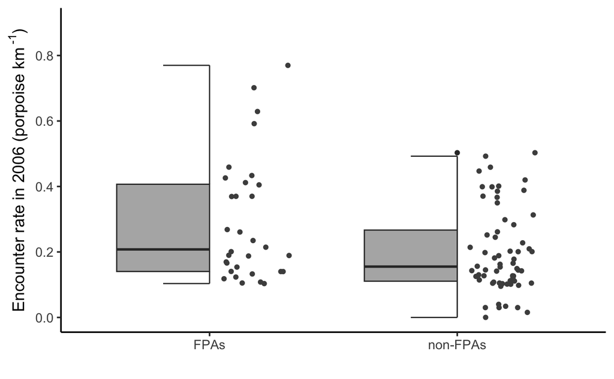

```r
abund_06 <- ggplot(seg_abund_wide_exl, aes(x = reserve_without_nj, y=abund_06)) +
    geom_half_boxplot(fill="grey70")+
    geom_half_point(color="grey30")+
    scale_y_continuous(limits = c(0, 0.9), breaks=seq(0, 0.9, 0.2)) +
    scale_x_discrete(limits = c("Y", "N"),
                     breaks = c("Y", "N"),
                     labels = c("FPAs", "non-FPAs")) +
    labs (x = "", y = expression(paste("Encounter rate in 2006 ", "(", "porpoise km"^" -1", ")"))) +
    theme_classic(base_size = 14) +
    theme(legend.position.inside = c(.99, .99),
          legend.justification = c("right", "top"),
          legend.box.just = "right")
abund_06
```

**Plot porpoise abundance in 2017 (PAs v.s. non-PAs)**

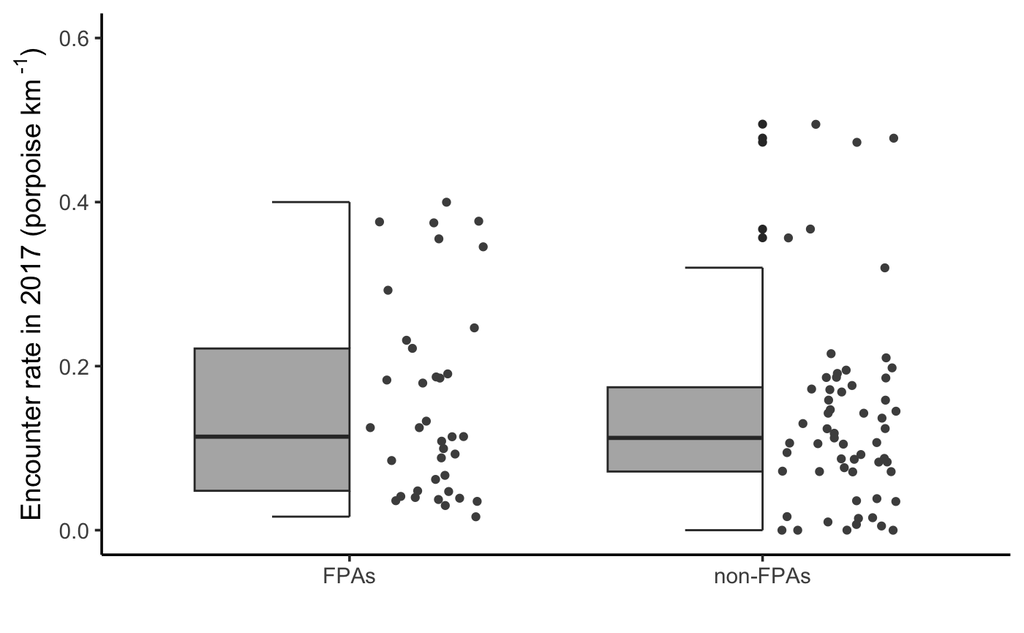

```r
abund_17 <- ggplot(seg_abund_wide_exl, aes(x = reserve, y=abund_17)) +
    geom_half_boxplot(fill="grey70")+
    geom_half_point(color="grey30")+
    scale_y_continuous(limits = c(0, 0.6), breaks=seq(0, 0.6, 0.2)) +
    scale_x_discrete(limits = c("Y", "N"),
                     breaks = c("Y", "N"),
                     labels = c("FPAs", "non-FPAs")) +
    labs (x = "", y = expression(paste("Encounter rate in 2017 ", "(", "porpoise km"^" -1", ")"))) +
    theme_classic(base_size = 14) +
    theme(legend.position = c(.99, .99),
          legend.justification = c("right", "top"),
          legend.box.just = "right")
abund_17
```

**Plot DiD analysis results**

```r
data_summary <- seg_abund_wide_exl_binary %>%
  group_by(PA, year) %>%
  summarise(Abundance = mean(abundance), .groups = 'drop') |>
  mutate()

data_summary
```

| PA | year | Abundance |
| --- | --- | --- |
| 0 | 2006 | 0.1901780 |
| 0 | 2017 | 0.1349153 |
| 1 | 2006 | 0.2919730 |
| 1 | 2017 | 0.1548378 |

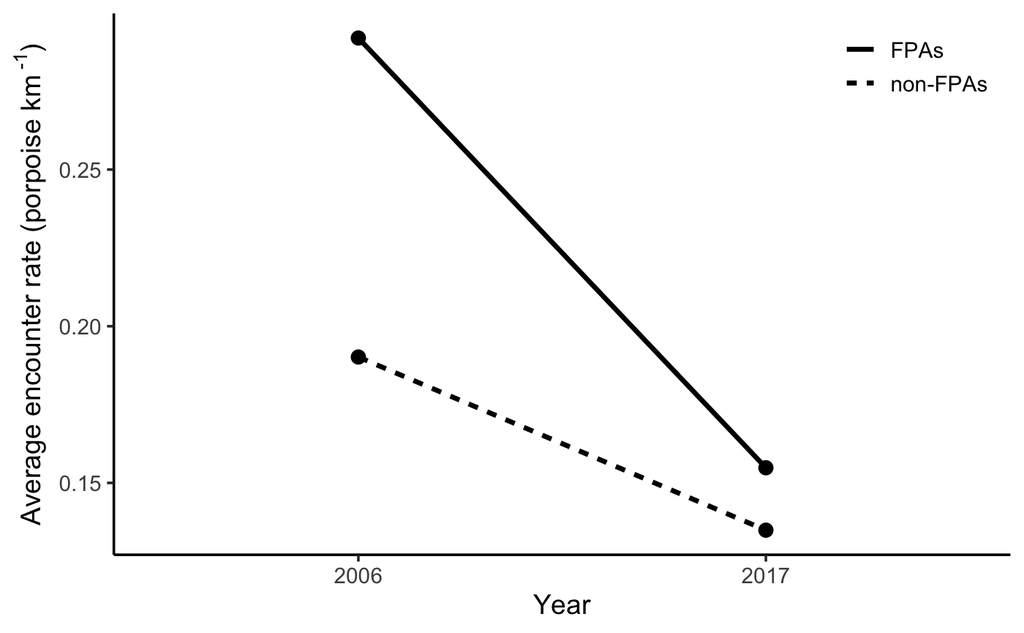

```r
data <- data.frame(
  Group = rep(c("FPAs", "non-FPAs"), each = 2),
  Year = rep(c("2006", "2017"), 2),
  Abundance = c(0.2919730, 0.1548378, 0.1901780, 0.1349153)  # Sample mean values
)

abund_change <- ggplot(data, aes(x = Year, y = Abundance, group = Group)) +
  geom_line(aes(linetype = Group), linewidth = 1.2) +
  geom_point(size = 3) +
  # scale_color_manual(values = c("FPA" = "black", "non-FPA" = "black")) +
  labs(x = "Year",
       y = expression(paste("Average encounter rate ", "(", "porpoise km"^" -1", ")"))
       ) +
  theme_classic(base_size = 14) +
  theme(legend.position = c(.99, .99),
        legend.justification = c("right", "top"),
        legend.box.just = "right",
        legend.title = element_blank())
abund_change
```

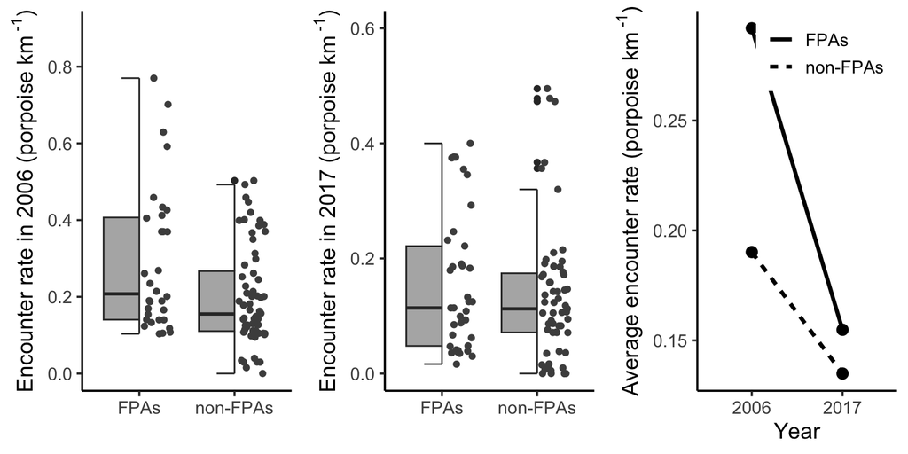

```r
combined_plot <- grid.arrange(abund_06, abund_17, abund_change, ncol = 3)
```

```r
combined_plot
```

[output not shown]

```r
ggsave("../../results/figures/fig_4_porpoise_abundance_did.png", combined_plot, width = 12, height = 4)
```